# Data Visualization Project 2: Analysis of the World Happiness dataset

Author

Caroline Graebel, Nina Immenroth, Bogdan Kostić, Naim Zahari

# 1 Top Level analysis of the data

## 1.2 Looking at distribution of the happiness score

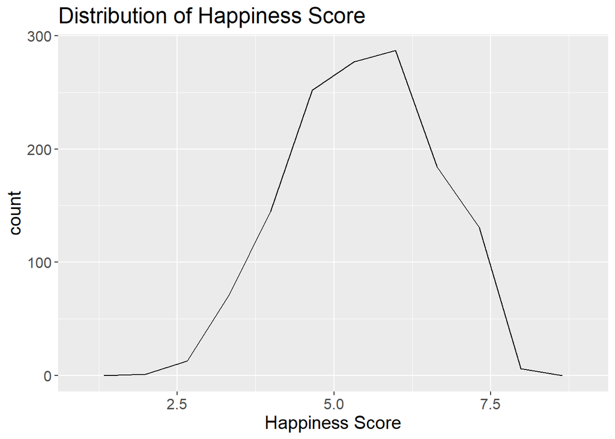

When looking at our variable of interest, it’s clearly visible that the distribution is quite close to a normal distribution.

## 1.3 Looking into relationship of the happiness score to predictors

### 1.3.1 Region

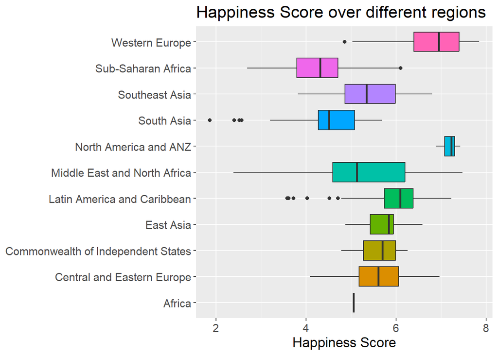

When looking at how the happiness score is connected to the regions of the countries we have data for, we can see that they differ a lot in their spread. Western Europe and North America and ANZ have the comparitively highest median happiness scores. In contrast, for Sub-Saharan Africa and South Asia the median happiness is the lowest. The regions also differ strongly in the variance. The variables within the first and third quarter percentiles cover a big range in the Middle East and North Africa while for Africa and North America the boxes are very small.  
Regions is understood as an aggregation for the variable country, as there are a big number of countries covered that it is not possible to visualize it. We are looking into countries that show interesting patterns later in the report.

### 1.3.2 GDP per Capita

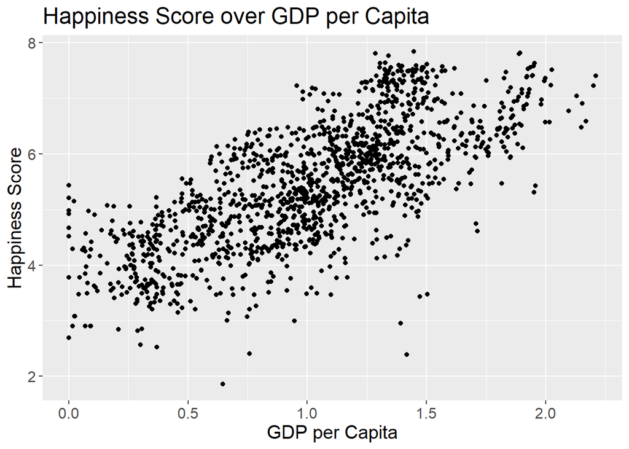

There seems to be a positive linear relationship between GDP per capita and the happiness score, as with higher GDP the happiness score rises. The relationship is stronger than it seems from the plot, as the scale ratio of x- and y-axis are so different. Calculating the correlation helps with providing further prove for the linear relationship between the variables.

```
Correlation of the happiness score and GDP per capita: 0.7238105
```

The correlation of these variables - as expected - is very high.

### 1.3.3 Social Support

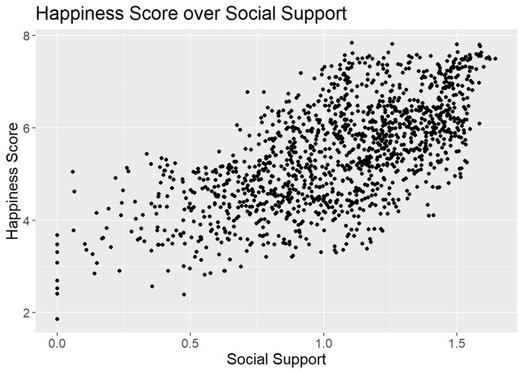

Similar to GDP per Capita, there is a positive linear relationship between both variables.

```
Correlation of the happiness score and social support: 0.6481553
```

The correlation between social support and happiness score isn’t as strong as for GDP per capita but still very strong.

### 1.3.4 Healthy life expectancy

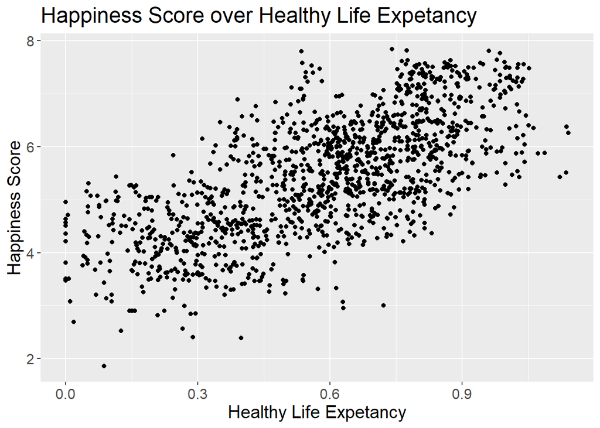

Here, we again have a positive linear relationship between the two variables. Interestingly, for healthy life expectancy some values are missing.

```
Correlation of the happiness score and healthy life expectancy: 0.6823998
```

There a strong positive correlation between healthy life expectancy and the happiness score.

### 1.3.5 Freedom to make life choices

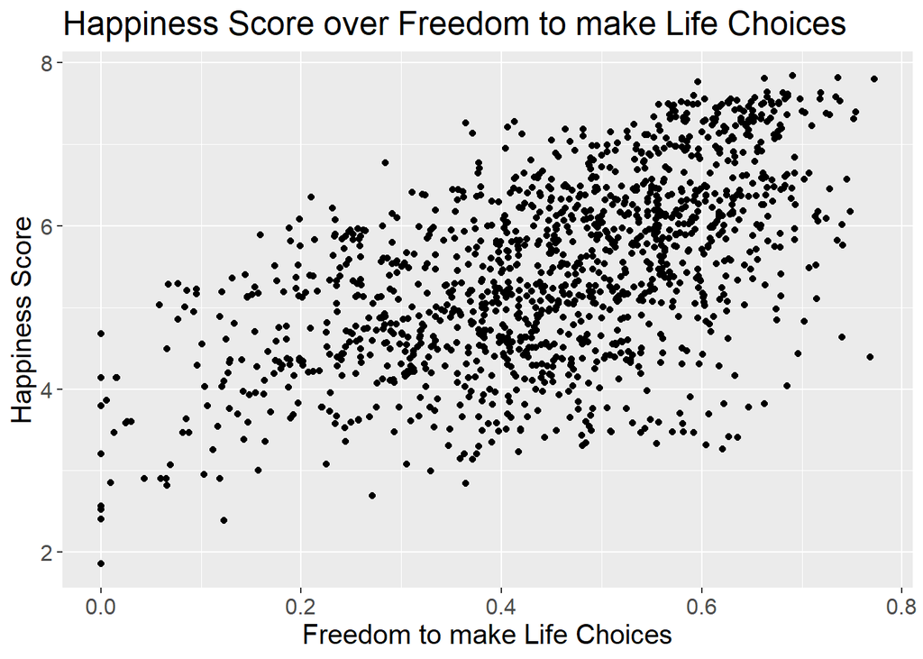

In this case, there also is a positive linear relationship between freedom to make life choices and happiness score, even though it seems a bit weaker than with the variables discussed so far.

```
Correlation of the happiness score and freedom to make life choices: 0.5694581
```

In general, there is a strong positive correlation between the variables but it is the weakest so far.

### 1.3.6 Generosity

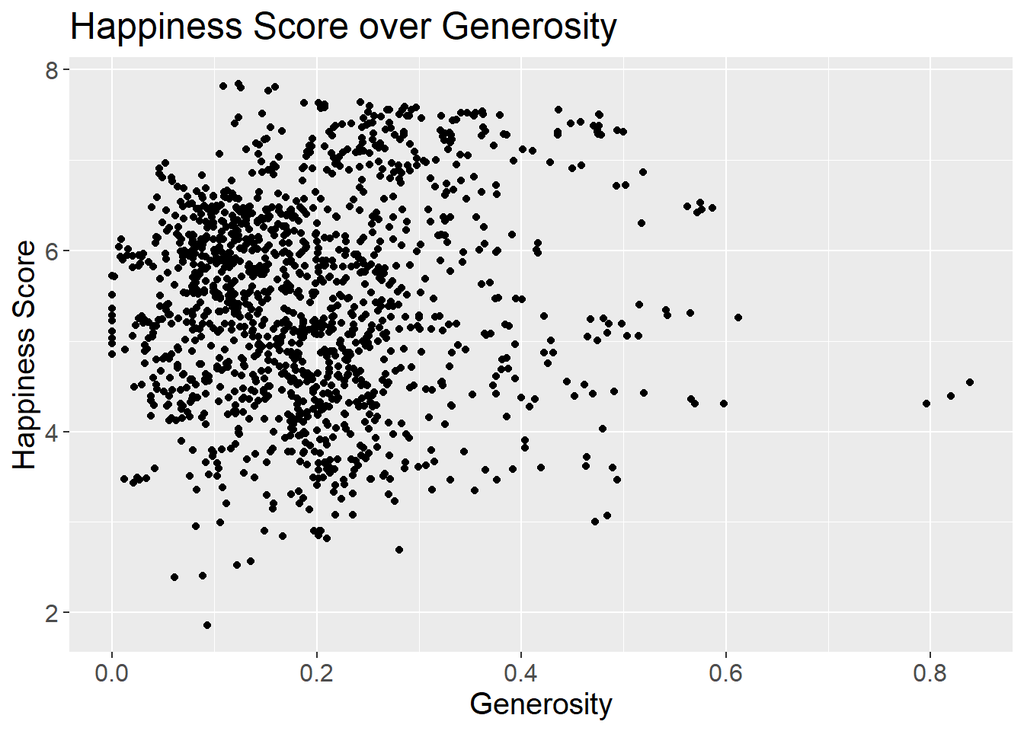

There is no connection between the variables visible here.

### 1.3.7 Perceptions of corruption

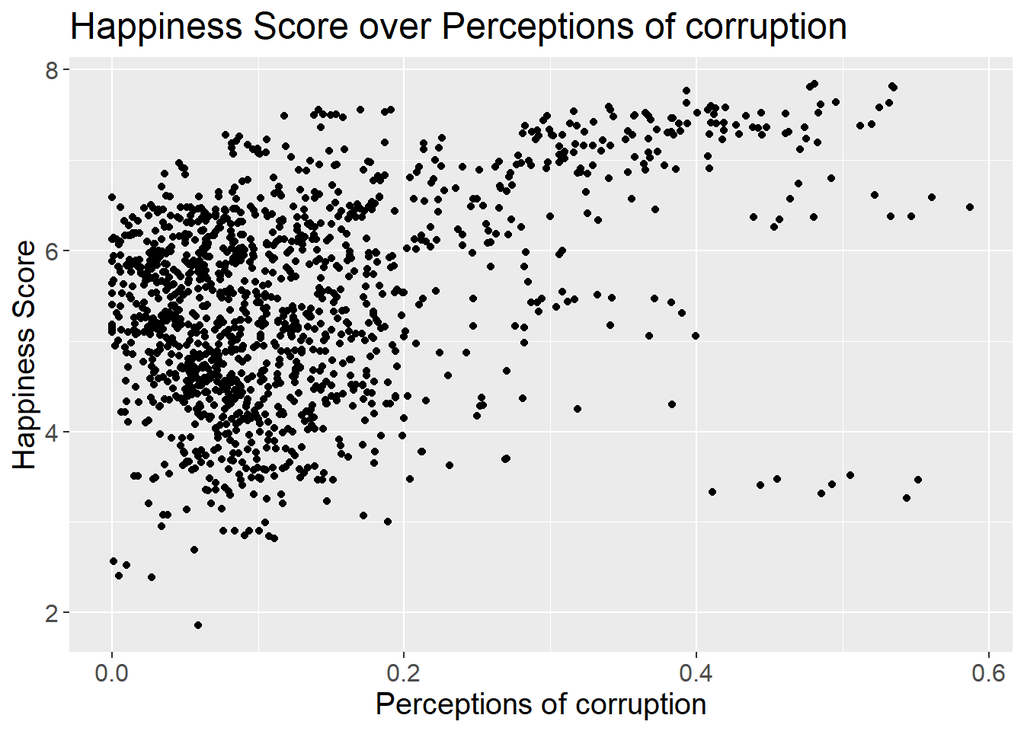

For perceptions of corruption, there seems to be a slight upward trend in happiness score for higher perceptions of corruption but it’s only a fraction of data points that score high on perceptions of corruption. Also there is missing data for this variable.

```
[1] 0.4150709
```

Calculationg the correlation shows that there is again a positive correlation between the two variables, even if it appears weak compared to other variables that have been looked at-

### 1.3.8 Year

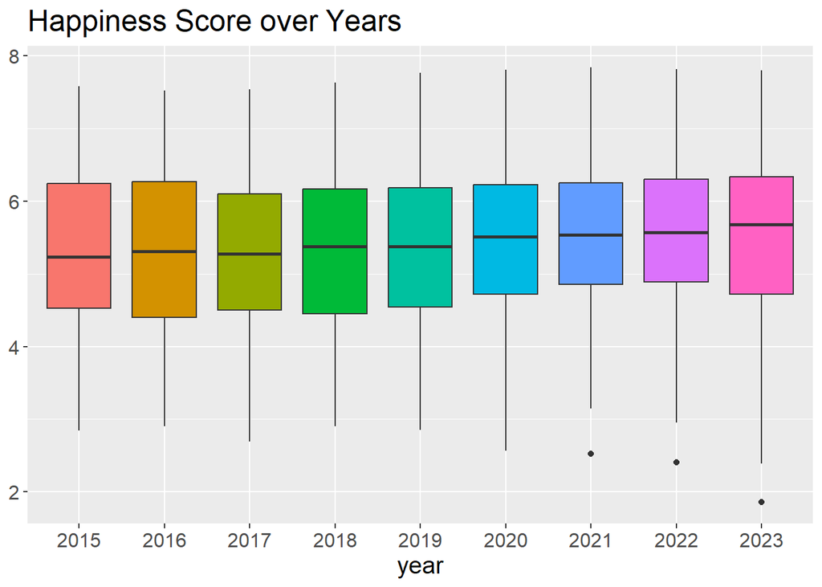

For medians, there is a slight upwards trend over the years, which 2020 to 2022 having little variance compared to th other years. There are also negative outliers for 2021 to 2023.

## 1.4 Using K-means Clustering to find interesting patterns

It is the goal to use K-means clustering to provide a pattern that is interpretable and give further context to the relationship between the happiness score and other variables. The procedure will first be introduced, then the data is scaled for an optimal performance and the best amount of clusters will be chosen by using the elbow-criteria to sensibly minimize total within sum-of-squares. At the end, a final model is trained and the result is plotted.  
It is important to mention that K-Means can only be used for continuous variables, so country, region, and year are not considered here.

### 1.4.1 Introduction K-Means

K-Means Clustering is an unsupervised machine learning method that can help classify data that has no label that a model could be trained on. This is made possible by a distance-based approach that fits the clusters so that the distances between the data points within a cluster are minimal. The distance in this case is a measure of similarity between data points, so in other words we want to fit clusters so that the points contained in one cluster are as similar as possible.

### 1.4.2 Trying PCA to improve K-Means performance

A good measure for improving the performance of K-Means is doing PCA on the data as it can aggregate the information. However, PCA is only useful if you can cover around 80% of the data with only few principle components.

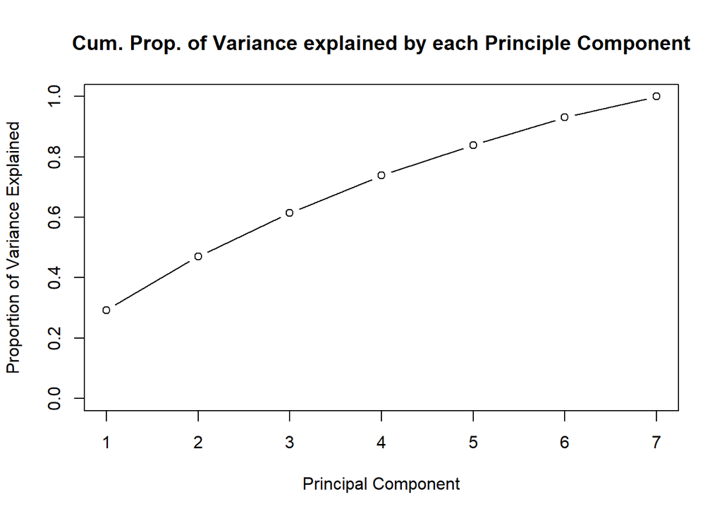

As can be seen, it would be necessary to use four to five of seven variables to cover a sufficient amount of variance. Since this isn’t too helpful and each principle component contains a similar amount of variance, there will be no PCA used before doing K-Means.

### 1.4.3 Finding a good amount of clusters

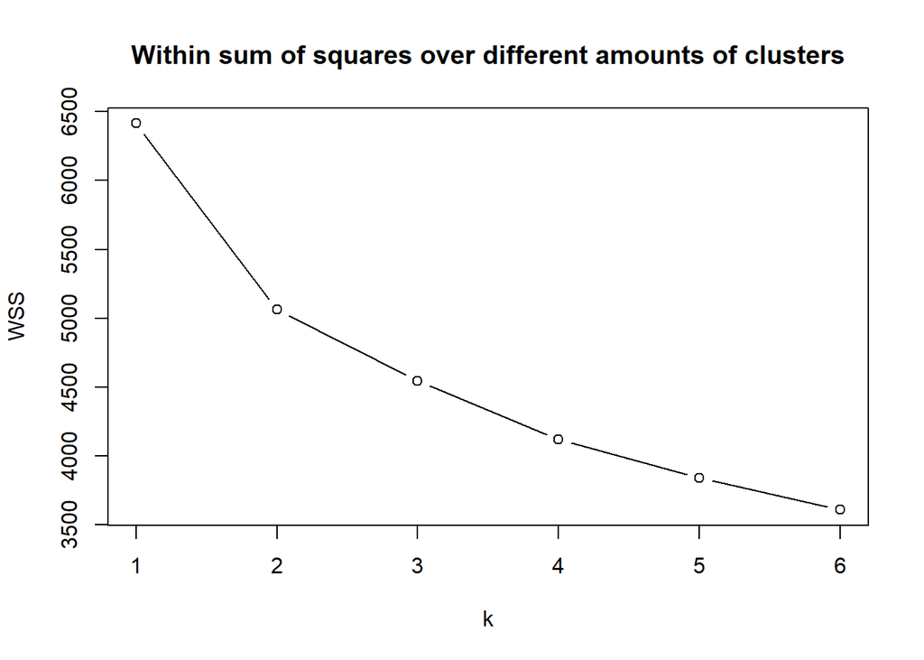

Using the elbow criterium, it can be seen that after k = 2, the decrease of within sum of squares isn’t as strong anymore. Therefore, the final K-Means model is trained with two clusters.

### 1.4.4 Resulting plots

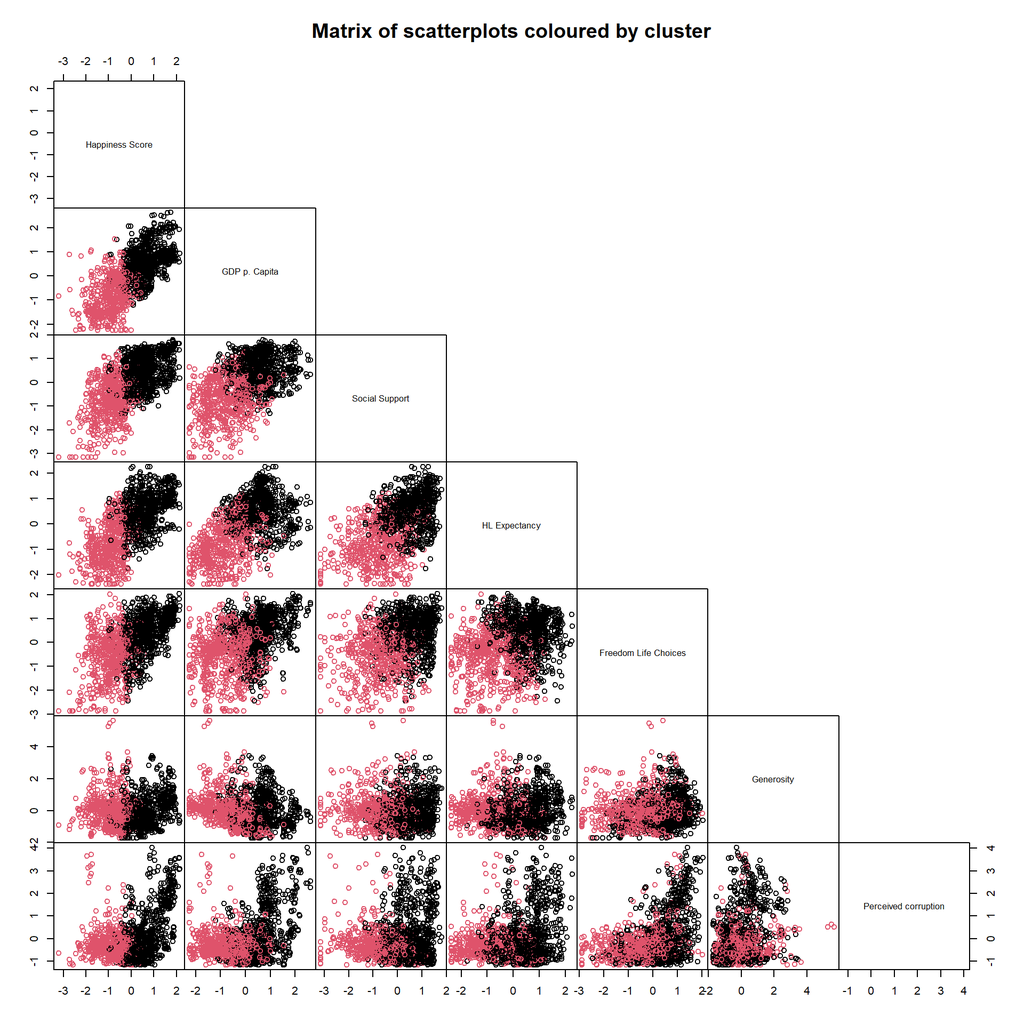

When looking at the scatterplots, the first thing to be noted is that for happiness score, there is the cleanest split between the clusters which basically splits the plot into a happiness score that is bigger than 0 and vice versa. In other words, the clusters are strongly informed by whether the happiness score is in the upper 50% quantile or below.

```
Median of the happiness score: -0.0004473365
```

For further context, the median value of the happiness score is almost perfectly zero. From the initial plots it has been shown that the happiness score correlates with all variables plotted here except for generosity. From the matrix of scatterplots we can gather that all plots within the matrix show the same pattern of the red cluster being in the lower left and the black cluster in the upper.

## 1.5 Using Random Forest to rank feature importance

When training a random forest on data, multiple trees are fitted on random subsets of data with only using a subset of variables in each iteration. There are two different types of variable importance the resulting plot provides.

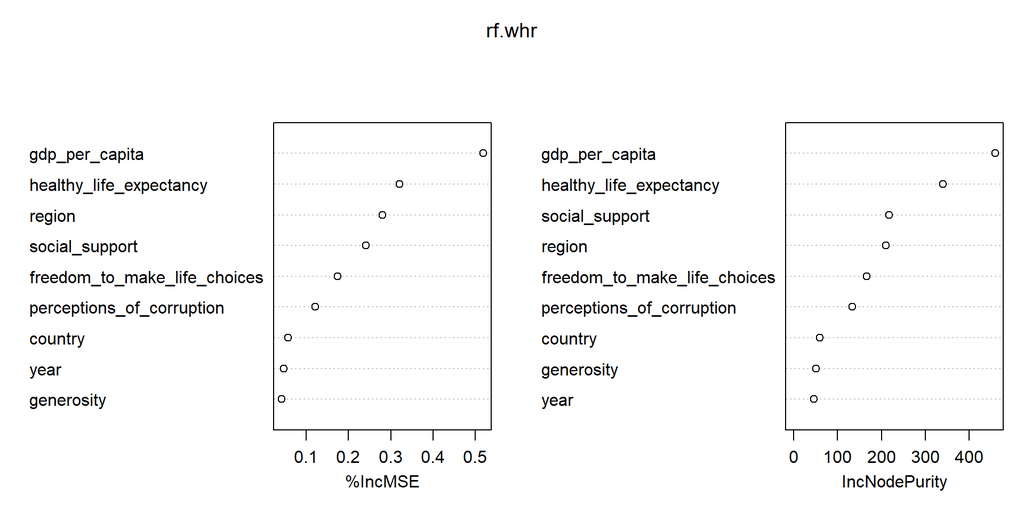

The first one is an increase or decrease in the mean squared error of the tree, which gives a top level information on how far off the actual data is from the predicted values. The variables are ordered by how much the variables impact the mean squared error when being applied. From this example, GPD per capita improves the trees the most as it lowers the MSE a lot and vice versa - when it is missing, the MSE is higher.  
Node Purity on the other hand represents how well the tree splits the data. In simple words, it contains information on how often a variable is used to split branches in the tree and how many observations are processed by this split. The more observations this variable splits and the more often it’s used, the more importance is the variable.  
When predicting the happiness score, GDP per capita and healthy life expectancy are ranked the highest for both importancy measures. This coincides with the high correlations that have been measured for the scatterplots between happiness score and the two variables.  
An important thing to keep in mind is that there’s an element of randomness in these results. For different seeds, the top four variables are stable, but how important they are and their ranking can be different. It also should be noted at an increased MSE of 20% for example freedom to make life choices is still a strong impact, even if this variable appears of low rank compared to others.